# Spotrebiteľský výskum

Blok 6 · cvičenia 10 – 12

Senzometria v R · SaIT

## Trvanlivosť očami spotrebiteľa

- Mikrobiologická trvanlivosť: kedy je produkt **nebezpečný**
- Senzorická trvanlivosť: kedy ho spotrebiteľ **odmietne**

Udalosť = **odmietnutie**. Ak hodnotiteľ produkt do konca testu neodmietol, jeho údaj je **cenzúrovaný** – vieme len, že vydržal aspoň tak dlho. Presne s tým pracuje analýza prežitia.

## Kaplan-Meierova krivka

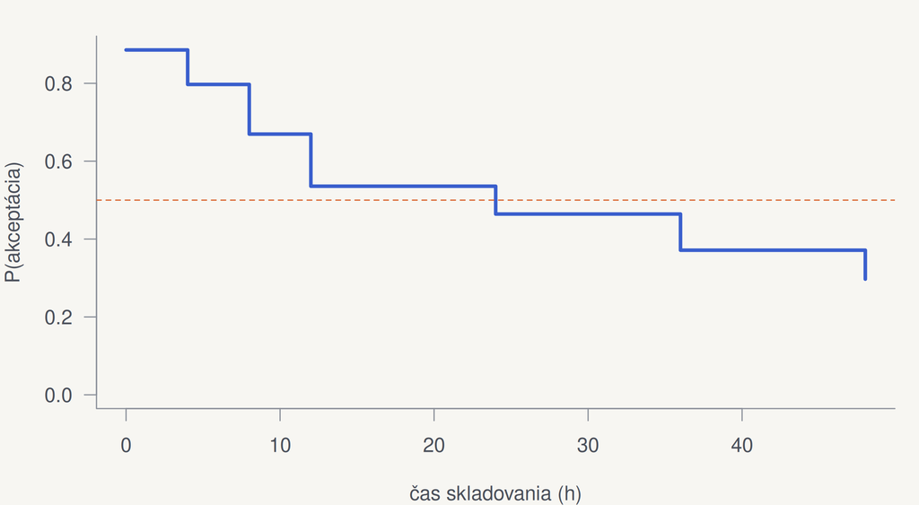

```r
cas <- rep(c(0, 4, 8, 12, 24, 36, 48), 5)
odmietol <- c(1,1,1,1,0,0,0, 1,1,1,1,1,1,1,
              1,1,0,1,0,0,0, 1,0,1,0,0,0,0,
              0,0,1,1,1,1,0) == 1
fit <- survfit(Surv(cas, odmietol) ~ 1)
plot(fit, conf.int = FALSE, lwd = 3,
     col = pal[3], xlab = "čas skladovania (h)",
     ylab = "P(akceptácia)")
abline(h = 0.5, col = pal[2], lty = 2)
```

```r
fit
```

```
Call: survfit(formula = Surv(cas, odmietol) ~ 1)

      n events median 0.95LCL 0.95UCL
[1,] 35     20     24      12      NA
```

Medián senzorickej trvanlivosti = čas, keď krivka klesne pod 0,5.

## TURF – dosah a frekvencia

Pizzeria môže ponúknuť len 3 – 4 ingrediencie. Nechceme **najobľúbenejšie**, ale tie, ktoré **spolu oslovia najviac rôznych** zákazníkov.

| ukazovateľ | otázka |
| --- | --- |
| **Reach** | koľko % zákazníkov má rado aspoň jednu položku? |
| **Frequency** | koľko obľúbených položiek má zákazník v priemere? |

## TURF v praxi

```r
set.seed(11)
n <- 150
p <- c(syr = 0.7, sunka = 0.6, salama = 0.55, olivy = 0.3, kukurica = 0.35, slanina = 0.4)
chuti <- sapply(p, function(pi) rbinom(n, 1, pi))
kombinacie <- combn(names(p), 3)
reach <- apply(kombinacie, 2, function(k) mean(rowSums(chuti[, k]) > 0))
naj <- order(reach, decreasing = TRUE)[1:4]
data.frame(kombinacia = apply(kombinacie[, naj], 2, paste, collapse = " + "), reach = round(reach[naj], 3))
```

```
               kombinacia reach
1    syr + sunka + salama 0.960
2  syr + salama + slanina 0.953
3 syr + salama + kukurica 0.947
4     syr + sunka + olivy 0.940
```

Balík `turfR` robí to isté pre všetky kombinácie a pridáva frekvenciu a váhy respondentov.

## Mapa preferencií

- **Senzorický profil** (panel): *aký* produkt je
- **Hedonika** (spotrebitelia): *ako veľmi* sa páči
- `carto()` premietne preferencie do PCA mapy profilu

```r
library(SensoMineR)
res.pca <- PCA(senzorika)
carto(res.pca$ind$coord[, 1:2],
      hedonika)
```

Vrstevnice ukazujú **percento spokojných spotrebiteľov**. Smer od nášho produktu k „ideálnej zóne“ napovie, ktoré deskriptory posilniť.

## Text mining: od recenzií k číslam

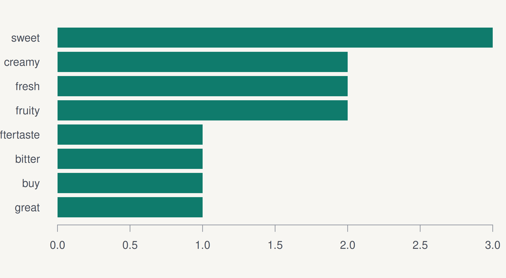

```r
recenzie <- c("creamy and sweet, fresh fruity taste",
  "too sour, thin texture, high price",
  "creamy smooth sweet, great product",
  "bitter aftertaste, will not buy again",
  "fresh fruity, pleasant surprise, sweet")
slova <- unlist(strsplit(gsub("[[:punct:]]", "",
                              recenzie), " +"))
stop <- c("and", "not", "will", "too", "again")
frek <- sort(table(slova[!slova %in% stop]),
             decreasing = TRUE)[1:8]
barplot(rev(frek), horiz = TRUE, las = 1,
        col = pal[1], border = NA)
```

Pred počítaním treba text **vyčistiť**: malé písmená, bez interpunkcie a stop-slov. Balík `tm` na to má `tm_map()`.

## Analýza sentimentu – lexikón NRC

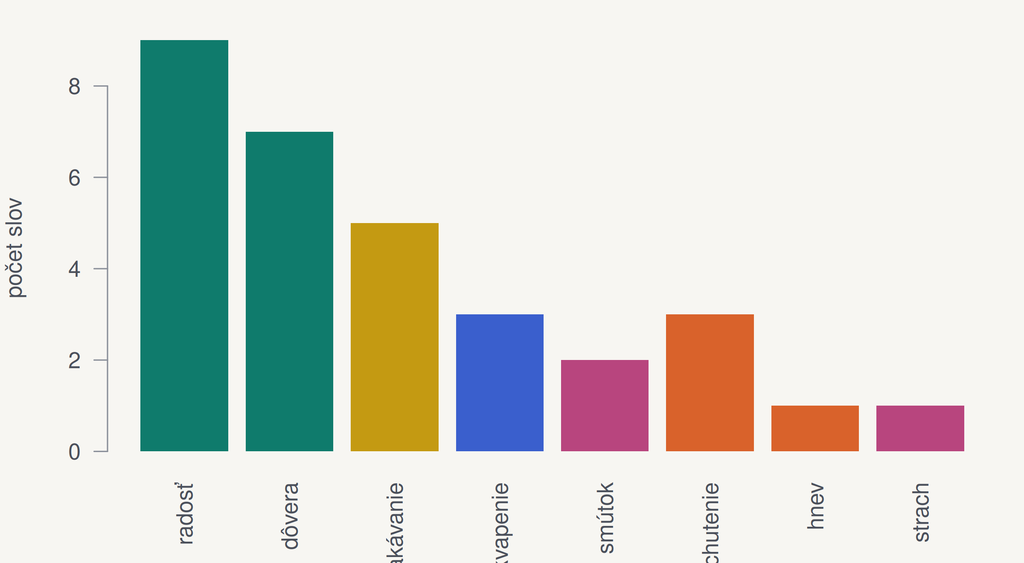

`get_nrc_sentiment()` priradí slovám 8 emócií Plutchikovho kolesa a polaritu. Ilustračné hodnoty; lexikón nevidí kontext („not sweet at all“).

## JAR škála

**Kód**

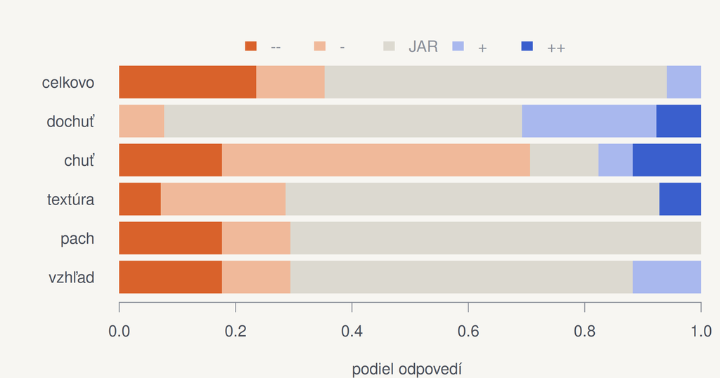

```r
jar <- matrix(c(3, 2, 10, 2, 0, 3, 2, 12, 0, 0, 1, 3, 9, 0, 1, 3, 9, 2, 1, 2, 0, 1, 8, 3, 1, 4, 2, 10, 1, 0),
  ncol = 5, byrow = TRUE, dimnames = list(c("vzhľad", "pach", "textúra", "chuť", "dochuť", "celkovo"),
                                          c("--", "-", "JAR", "+", "++")))
podiel <- prop.table(jar, 1)
par(mar = c(4, 6, 3, 1))
barplot(t(podiel), horiz = TRUE, las = 1, col = c(pal[2], "#f0b99a", "#dcd9d0", "#a9b8ee", pal[3]),
        border = NA, xlab = "podiel odpovedí")
legend("top", legend = colnames(jar), fill = c(pal[2], "#f0b99a", "#dcd9d0", "#a9b8ee", pal[3]),
       horiz = TRUE, bty = "n", inset = -0.12, xpd = TRUE, border = NA)
```

Chuť má len 12 % odpovedí „akurát“ a väčšina ju považuje za slabú → posilniť chuť je priorita.

## KVÍZ Čo upraviť?

Pri sladkosti je 60 % JAR, 30 % „príliš sladké“ a 10 % „málo sladké“. Čo navrhnete?

Mierne **znížiť sladkosť** – nadpolovičná JAR, ale jasná asymetria na stranu „príliš“. Pred zmenou overte **penalty analýzou**, či táto skupina produkt aj horšie hodnotí.

## Radarový graf (profilogram)

**Kód**

```r
library(fmsb)
profil <- data.frame(
  Vzhlad = c(9, 0, 5.2, 7), Textura = c(9, 0, 4.5, 4.8),
  Pach = c(9, 0, 3.8, 5.8), Chut = c(9, 0, 8, 8),
  Dochut = c(9, 0, 8, 8))
par(mar = c(1, 1, 1, 1))
radarchart(profil, pcol = pal[2:3], plwd = 3,
           plty = 1, cglcol = "grey70", vlcex = 1.1)
legend("topright", c("A", "C"), col = pal[2:3],
       lwd = 3, bty = "n")
```

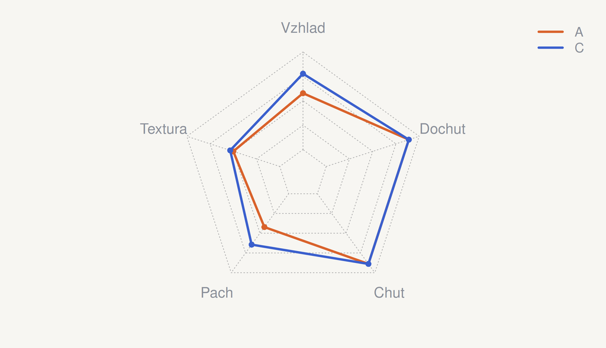

Prvé dva riadky dát sú maximum a minimum osí. Pozor – plocha polygónu závisí od poradia osí.

## Zhrnutie

| otázka | metóda |
| --- | --- |
| dokedy je produkt akceptovaný? | Kaplan-Meier, cenzúrované dáta |
| ktorá kombinácia osloví najviac ľudí? | TURF (reach, frequency) |
| prečo sa produkty páčia? | mapa preferencií |
| čo hovoria recenzie? | text mining, sentiment |
| čo zmeniť v receptúre? | JAR + penalty analýza |

Teória 10 Teória 11a Teória 11b Teória 12